# Simulation

James M. Flegal

## Agenda

- Simulating from distributions
- Quantile transform method
- Rejection sampling

## Simulation

Why simulate?

- We want to see what a probability model actually does
- We want to understand how our procedure works on a test case
- We want to use a partly-random procedure

All of these require drawing random variables from distributions

## Simulation

We have seen R has built in distributions: `beta`, `binom`, `cauchy`, `chisq`, `exp`, `f`, `gamma`, `geom`, `hyper`, `logis`, `lnorm`, `nbinom`, `norm`, `pois`, `t`, `tukey`, `unif`, `weibull`, `wilcox`, `signrank`

Every distribution that R handles has four functions.

- `p` for "probability", the cumulative distribution function (c. d. f.)
- `q` for "quantile", the inverse c. d. f.
- `d` for "density", the density function (p. f. or p. d. f.)
- `r` for "random", a random variable having the specified distribution

## Simulation

- Usually, R gets Uniform$(0,1)$ random variates via a pseudorandom generator, e.g. the linear congruential generator
- Uses a sequence of Uniform$(0,1)$ random variates to generate other distributions
- How?

## Example: Binomial

- Suppose we want to generate a Binomial$(1,1/3)$ using a $U \sim \text{Uniform}(0,1)$
- Consider the function $X^* = I(0<u<1/3)$, then
  $$P(X^* = 1) = P( I(0<u<1/3 = 1) = P( u \in (0,1/3)) = 1/3$$
  and $P(X^* = 0) = 2/3$
- Hence, $X^* \sim \text{Binomial}(1,1/3)$
- Two ways to extend this to Binomial$(n,1/3)$

## Example: Binomial

```r
my.binom.1 <- function(n=1, p=1/3){
  u <- runif(n)
  binom <- sum(u<p)
  return(binom)
}

my.binom.1(1000)
```

```
## [1] 354
```

```r
my.binom.1(1000, .5)
```

```
## [1] 525
```

## Example: Binomial

```r
my.binom.2 <- function(n=1, p=1/3){
  u <- runif(1)
  binom <- qbinom(u, size=n, prob=p)
  return(binom)
}

my.binom.2(1000)
```

```
## [1] 349
```

```r
my.binom.2(1000, .5)
```

```
## [1] 493
```

## Quantile transform method

Given $U \sim \text{Uniform}(0,1)$ and CDF $F$ from a continuous distribution. Then $X = F^{-1}(U)$ is a random variable with CDF $F$.

Proof:

$$P(X\le a) = P (F^{-1}(U) \le a) = P ( U \le F(a)) = F(a)$$

- $F^{-1}$ is the quantile function
- If we can generate uniforms and calculate quantiles, we can generate non-uniforms
- Also known as the Probability Integral Transform Method

## Example: Exponential

Suppose $X \sim \text{Exp}(\beta)$. Then we have density

$$f(x) = \beta^{-1} e^{-x/\beta} I(0<x<\infty)$$
and CDF
$$F(x) = 1 - e^{-x/\beta}$$
Also
$$y = 1 - e^{-x/\beta} \text{ iff } -x/\beta = \log (1-y) \text{ iff } x = -\beta \log (1-y).$$
Thus, $F^{-1} (y) = -\beta \log(1-y)$.

So if $U \sim \text{Uniform}(0,1)$, then $F^{-1} (u) = -\beta \log(1-u) \sim \text{Exp}(\beta)$.

## Example: Exponential

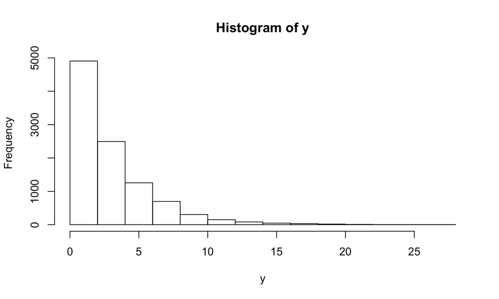

```r
x <- runif(10000)
y <- - 3 * log(1-x)
hist(y)
```

```r
mean(y)
```

```
## [1] 2.98428
```

## Example: Exponential

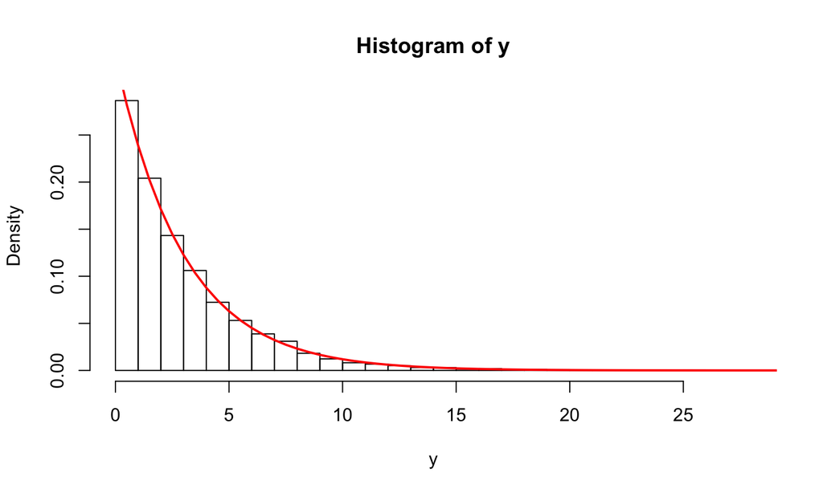

```r
true.x <- seq(0,30, .5)
true.y <- dexp(true.x, 1/3)
hist(y, freq=F, breaks=30)
points(true.x, true.y, type="l", col="red", lw=2)
```

## Example: Gamma

- Remember that if $X_1, \dots, X_n$ are IID $\text{Exp}(\beta)$, then $\sum_{i=1}^n X_i \sim \Gamma(n, \beta)$
- Hence if we need a $\Gamma(\alpha, \beta)$ random variate and $\alpha \in \{ 1, 2, \dots \}$, then take $U_1, \dots, U_{\alpha}$ IID $\text{Uniform}(0,1)$ and set
  $$\sum_{i=1}^{\alpha} -\beta \log(1-u_i) \sim \Gamma(\alpha, \beta)$$
- What if $\alpha$ is not an integer?

## Quantile transform method

- Quantile functions often donâ€™t have closed form solutions or even nice numerical solutions
- But we know the probability density function â€” can we use that?

## Rejection sampling

- The *accept-reject algorithm* is an indirect method of simulation
- Uses draws from a density $f_y(y)$ to get draws from $f_x(x)$
- Sampling from the wrong distribution and correcting it

## Rejection sampling

Theorem: Let $X \sim f_x$ and $Y \sim f_y$ where the two densities have common support. Define

$$M = \sup_{x} \frac{f_x(x)}{f_y(x)}.$$
If $M< \infty$ then we can generate $X \sim f_x$ as follows,

1. Generate $Y \sim f_y$ and independently draw $U \sim \text{Uniform}(0,1)$
2. If
   $$u < \frac{f_x(y)}{M f_y(y)}$$
   set $X=Y$; otherwise return to 1.

Exercise: Why is $M\ge 1$?

## Rejection sampling

Proof:

$$\begin{aligned}
P(X \le x) & = P \left( Y \le x \; \middle| \; \text{STOP} \right)\\
& = P \left( Y \le x \; \middle| \; u \le \frac{f_x(y)}{M f_y(y)} \right) \\
& = \frac{P \left( Y \le x , u \le \frac{f_x(y)}{M f_y(y)} \right)}{P \left( u \le \frac{f_x(y)}{M f_y(y)} \right)} \\
& = \frac{A}{B}
\end{aligned}$$

## Rejection sampling

Now, we have

$$\begin{aligned}
A & = P \left( Y \le x , u \le \frac{f_x(y)}{M f_y(y)} \right) \\
& = E \left[ P \left( Y \le x , u \le \frac{f_x(y)}{M f_y(y)} \right) \; \middle| \; y \right] \\
& = E \left[ I (y \le x) \frac{f_x(y)}{M f_y(y)} \right] \\
& = \int_{-\infty}^{\infty} I (y \le x) \frac{f_x(y)}{M f_y(y)} f_y(y) dy \\
& = \frac{1}{M} \int_{-\infty}^{x} f_x(y) dy = \frac{F_x(x)}{M}
\end{aligned}$$

## Rejection sampling

Similarly, we have

$$\begin{aligned}
B & = P \left( u \le \frac{f_x(y)}{M f_y(y)} \right) \\
& = E \left[ P \left( u \le \frac{f_x(y)}{M f_y(y)} \right) \; \middle| \; y \right] \\
& = E \left[ \frac{f_x(y)}{M f_y(y)} \right] \\
& = \int_{-\infty}^{\infty} \frac{f_x(y)}{M f_y(y)} f_y(y) dy \\
& = \frac{1}{M} \int_{-\infty}^{\infty} f_x(y) dy = \frac{1}{M}
\end{aligned}$$

## Rejection sampling

Hence,

$$\begin{aligned}
P(X \le x) & = \frac{A}{B} \\
& = \frac{\frac{F_x(x)}{M}}{\frac{1}{M}} = F_x(x)
\end{aligned}$$
And the proof is complete. That is, $X \sim f_x$.

## Rejection sampling

- Notice,
  $$P(\text{STOP}) = B = P \left( u \le \frac{f_x(y)}{M f_y(y)} \right) = \frac{1}{M}$$
- Thus the number of iterations until the algorithm stops is Geometric($1/M$)
- Hence, the expected number of iterations until acceptance is $M$.

## Example: Gamma

- Suppose we want to simulate $X \sim \Gamma(3/2, 1)$ with density
  $$f_x(x) = \frac{2}{\pi} \sqrt{x} e^{-x} I(0<x<\infty).$$
- Can use the accept-reject algorithm with a $\Gamma(n,1)$ and $n \in \{ 1, 2, \dots \}$ since we know how to simulate this

## Example: Gamma

- Then we have
  $$\begin{aligned}
  M & = \sup_{x>0} \frac{f_x(x)}{f_y(x)}\\
  & = \sup_{x>0} \frac{\frac{2}{\pi} \sqrt{x} e^{-x}}{\frac{1}{(n-1)!} x^{n-1} e^{-x}}\\
  & = c \sup_{x>0} x^{-n+3/2} = \infty
  \end{aligned}$$
  since
  $$n < 3/2 \text{ implies } x^{-n+3/2} \to \infty \text{ as } x \to \infty$$
  and
  $$n > 3/2 \text{ implies } x^{-n+3/2} \to \infty \text{ as } x \to 0$$

## Example: Gamma

- Hence, we need to be a little more creative with our proposal distribution
- We could consider a mixture distribution. That is, if $f_1(z)$ and $f_2(z)$ are both densities and $p \in [0,1]$. Then
  $$p f_1(z) + (1-p) f_2(z)$$
  is also a density
- Consider a proposal that is a mixture of a $\Gamma(1,1) = \text{Exp}(1)$ and a $\Gamma(2,1)$, i.e.
  $$f_y(y) = \left[ p e^{-y} + (1-p) y e^{-y} \right] I(0 < y < \infty)$$

## Example: Gamma

Now, we have

$$\begin{aligned}
M & = \sup_{x>0} \frac{f_x(x)}{f_y(x)}\\
& = \sup_{x>0} \frac{\frac{2}{\pi} \sqrt{x} e^{-x}}{p e^{-x} + (1-p) x e^{-x}}\\
& = \frac{2}{\pi} \sup_{x>0} \frac{ \sqrt{x}}{p + (1-p) x} \\
& = \frac{2}{\pi} \frac{1}{2 \sqrt{p(1-p)}}
\end{aligned}$$
Exercise: Prove the last line, i.e. maximize $h(x) = \frac{ \sqrt{x}}{p + (1-p) x}$ for $x>0$ or $\log h(x)$.

## Example: Gamma

- Note that $M$ is minimized when $p=1/2$ so that $M_{1/2} = 2 / \sqrt{\pi} \approx 1.1283$.
- Then the accept-reject algorithm to simulate $X \sim \Gamma(3/2, 1)$ is as follows
1. Draw $Y \sim f_y$ with
   $$f_y(y) = \left[ p e^{-y} + (1-p) y e^{-y} \right] I(0 < y < \infty)$$
   and and independently draw $U \sim \text{Uniform}(0,1)$
2. If
   $$u < \frac{2}{\sqrt{\pi}} \frac{f_x(y)}{f_y(y)}=\frac{2 \sqrt{y}}{1+y}$$
   set $X=Y$; otherwise return to 1

## Simulating from mixtures

- Write $f(z) = p f_1(z) + (1-p) f_2(z)$ as the marginal of the joint given by
  $$f(z | w) = f_1(z) I(w=1) + f_2(z) I(w=0)$$
  where $W \sim \text{Binomial}(1,p)$
- Thus to simulate from $f(z)$
1. Draw $U \sim \text{Uniform}(0,1)$
2. If $u < p$ take $Z \sim f_1(z)$; otherwise take $Z \sim f_2(z)$
- Exercise: Show $Z \sim f(z)$

## Example: Gamma

```r
ar.gamma <- function(n=100){
x <- double(n)
i <- 1
while(i < (n+1)) {
    u <- runif(1)
    if(u < .5){
        y <- -1 * log(1-runif(1))
    } else {
        y <- sum(-1 * log(1-runif(2)))
    }
    u <- runif(1)
    temp <- 2 * sqrt(y) / (1+y)
    if(u < temp){
        x[i] <- y
        i <- i+1
    }
}
return(x)
}
```

## Example: Gamma

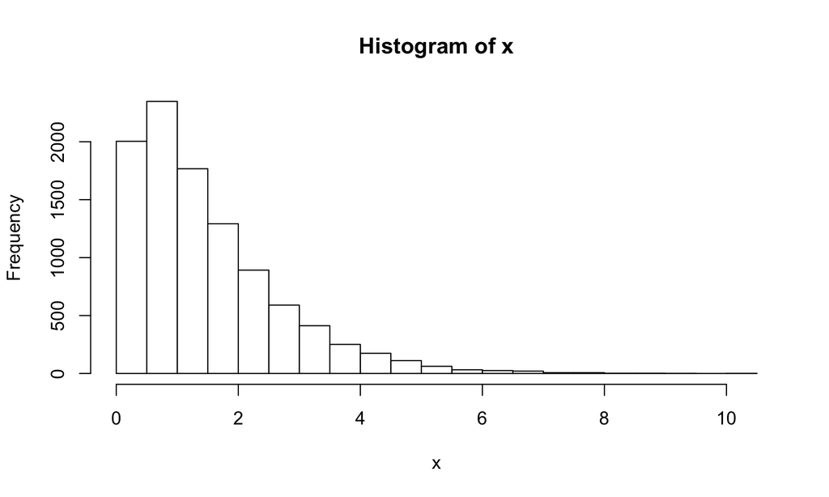

```r
x <- ar.gamma(10000)
hist(x)
```

```r
mean(x)
```

```
## [1] 1.482398
```

## Example: Gamma

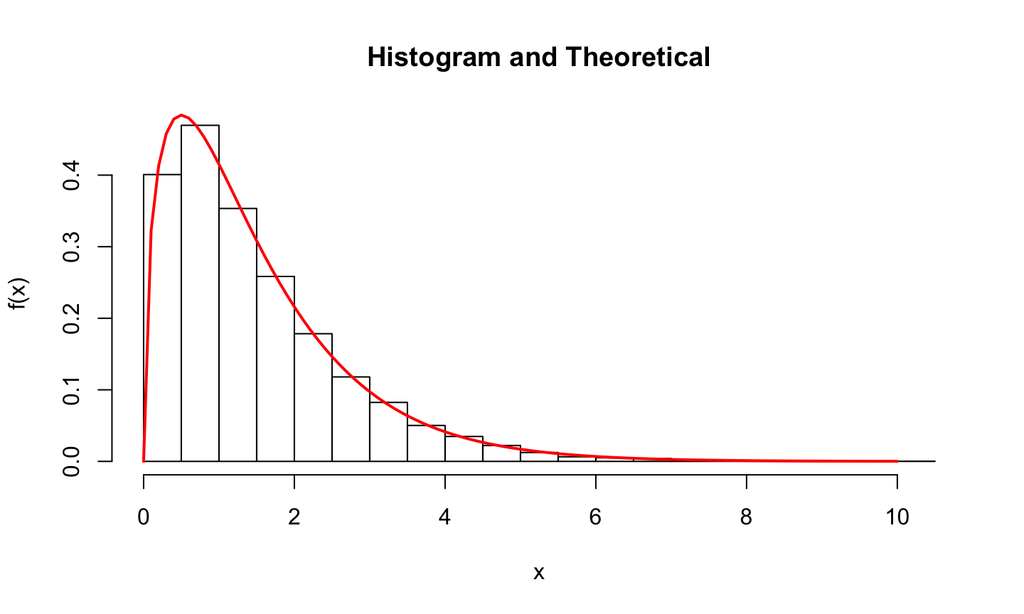

```r
true.x <- seq(0,10, .1)
true.y <- dgamma(true.x, 3/2, 1)
hist(x, freq=F, breaks=30, xlab="x", ylab="f(x)", main="Histogram and Theoretical")
points(true.x, true.y, type="l", col="red", lw=2)
```

## Example: Beta

Suppose the pdf $f$ is zero outside an interval $[c,d]$, and $\leq M$ on the interval.

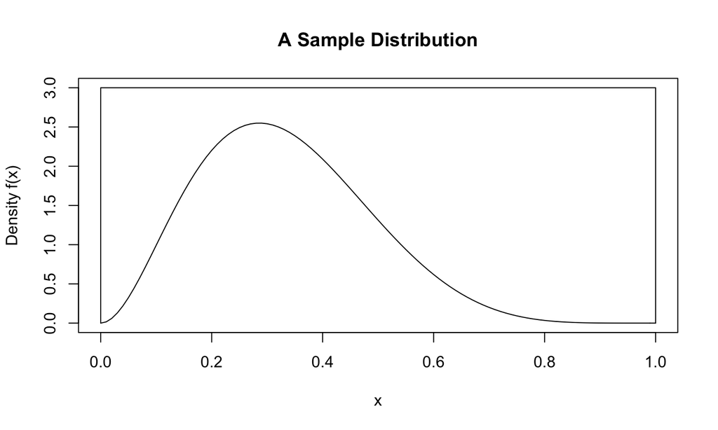

## Example: Beta

We know how to draw from uniform distributions in any dimension. Do it in two:

```r
x1 <- runif(300, 0, 1); y1 <- runif(300, 0, 2.6);
selected <- y1 < dbeta(x1, 3, 6)
```

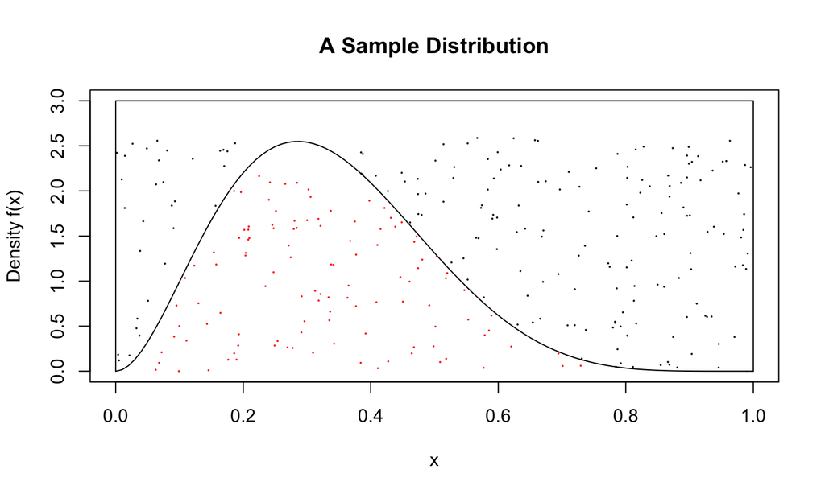

## Example: Beta

```r
mean(selected)
```

```
## [1] 0.3833333
```

```r
accepted.points <- x1[selected]
mean(accepted.points < 0.5)
```

```
## [1] 0.8521739
```

```r
pbeta(0.5, 3, 6)
```

```
## [1] 0.8554688
```

## Example: Beta

For this to work efficiently, we have to cover the target distribution with one that sits close to it.

```r
x2 <- runif(100000, 0, 1); y2 <- runif(100000, 0, 10);
selected <- y2 < dbeta(x2, 3, 6)
mean(selected)
```

```
## [1] 0.09907
```

## Example: Beta

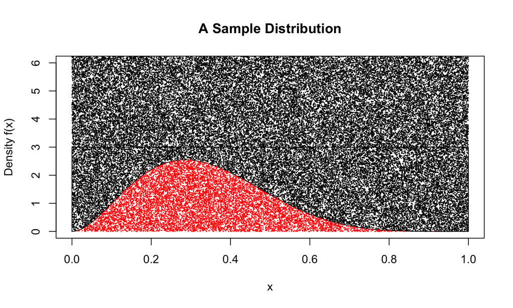

## Alternatives

- Squeezed rejection sampling may help if evaluating $f$ is expensive
- Adaptive rejection sampling may help generate an envelope
- …

## Box-Muller

- **Box-Muller transformation** transform generates pairs of independent, standard normally distributed random numbers, given a source of uniformly distributed random numbers
- Let $U \sim \text{Uniform}(0,1)$ and $V \sim \text{Uniform}(0,1)$ and set
  $$R=\sqrt{-2\log U} \hspace{10mm} \textrm{ and } \hspace{10mm} \theta = 2\pi V$$
- Then the following transformation yields two independent normal random variates
  $$X=R\cos(\theta) \hspace{10mm} \textrm{ and } \hspace{10mm} Y=R\sin(\theta)$$

## Summary

- Can transform uniform draws into other distributions when we can compute the distribution function
- Quantile method when we can invert the CDF
- The rejection method if all we have is the density
- Basic R commands encapsulate a lot of this for us
- Optimized algorithms based on distribution and parameter values

## Exercise: Box-Muller

1. Write a function named `bmnormal` that simulates `n` draws from Normal random variable with mean `mu` and standard deviation `sd` using the Box-Muller transformation.
2. Inputs to your function should be `n`, `mu`, and `sd`.
3. Simulate 2000 draws from a Normal with mean 10 and standard deviation 3.
4. Convince yourself with a plot your sampler is working correctly. Is there a test you could consider also?